# Peer-graded Assignment: Course Project

Eric Neil Pena

May 11, 2019

# Loading and Preprocessing the data

Install Required libraries

```r
chooseCRANmirror(graphics=FALSE, ind=1)

install.packages('lubridate')
install.packages('dplyr')
install.packages('lattice')
```

Load the required libraries

```r
chooseCRANmirror(graphics=FALSE, ind=1)

library(lubridate)
library(dplyr)
library(lattice)
```

download and unzip the file to get the actual csv file

```r
url <- "https://github.com/EricNeilMPena/RepData_PeerAssessment1/raw/master/activity.zip"
destination <- "dataset.zip"
download.file(url, destination)
```

```r
unzip(destination)
activity <- read.csv("activity.csv")
```

Get the Structure of the data by typing the following commands

```r
str(activity[which(!is.na(activity$steps)), ])
```

```
## 'data.frame':    15264 obs. of  3 variables:
##  $ steps   : int  0 0 0 0 0 0 0 0 0 0 ...
##  $ date    : Factor w/ 61 levels "2012-10-01","2012-10-02",..: 2 2 2 2 2 2 2 2 2 2 ...
##  $ interval: int  0 5 10 15 20 25 30 35 40 45 ...
```

```r
names(activity)
```

```
## [1] "steps"    "date"     "interval"
```

```r
summary(activity[which(!is.na(activity$steps)), ])
```

```
##      steps                date          interval
##  Min.   :  0.00   2012-10-02:  288   Min.   :   0.0
##  1st Qu.:  0.00   2012-10-03:  288   1st Qu.: 588.8
##  Median :  0.00   2012-10-04:  288   Median :1177.5
##  Mean   : 37.38   2012-10-05:  288   Mean   :1177.5
##  3rd Qu.: 12.00   2012-10-06:  288   3rd Qu.:1766.2
##  Max.   :806.00   2012-10-07:  288   Max.   :2355.0
##                   (Other)   :13536
```

```r
head(activity[which(!is.na(activity$steps)), ])
```

```
##     steps       date interval
## 289     0 2012-10-02        0
## 290     0 2012-10-02        5
## 291     0 2012-10-02       10
## 292     0 2012-10-02       15
## 293     0 2012-10-02       20
## 294     0 2012-10-02       25
```

Transform the data to be ready for analysis

```r
activity$date <- ymd(activity$date)
```

# What is the mean total number of steps taken per day

Calculate the total number of steps taken per day

```r
total_steps_per_day <- activity %>% group_by(date) %>% summarise(total_steps_per_day=sum(steps, na.rm=TRUE))
total_steps_per_day
```

```
## # A tibble: 61 x 2
##    date       total_steps_per_day
##    <date>                   <int>
##  1 2012-10-01                   0
##  2 2012-10-02                 126
##  3 2012-10-03               11352
##  4 2012-10-04               12116
##  5 2012-10-05               13294
##  6 2012-10-06               15420
##  7 2012-10-07               11015
##  8 2012-10-08                   0
##  9 2012-10-09               12811
## 10 2012-10-10                9900
## # ... with 51 more rows
```

Histogram of the total number of steps taken each day

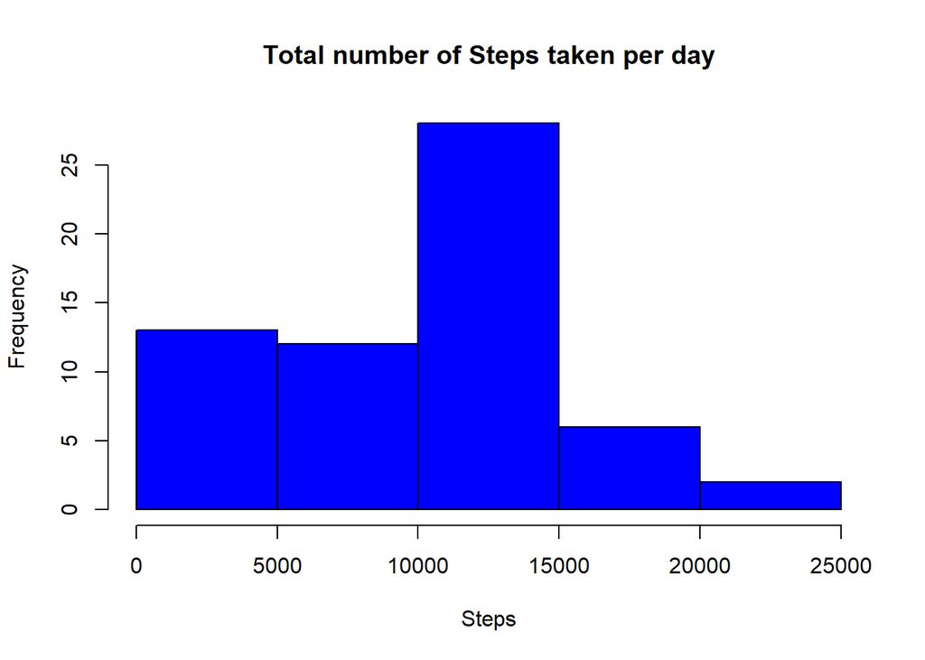

```r
hist(total_steps_per_day$total_steps_per_day,
     col="blue",
     xlab="Steps",
     ylab="Frequency",
     main="Total number of Steps taken per day")
```

Calculate and report the mean and median of the total number of steps taken per day

```r
total_steps_mean <- mean(total_steps_per_day$total_steps_per_day,na.rm=TRUE)
total_steps_mean
```

```
## [1] 9354.23
```

```r
total_steps_median <- median(total_steps_per_day$total_steps_per_day,na.rm=TRUE)
total_steps_median
```

```
## [1] 10395
```

# What is the average daily pattern

1.) Make a time series plot (i.e. type = “l”) of the 5-minute interval (x-axis) and the average number of steps taken, averaged across all days (y-axis)

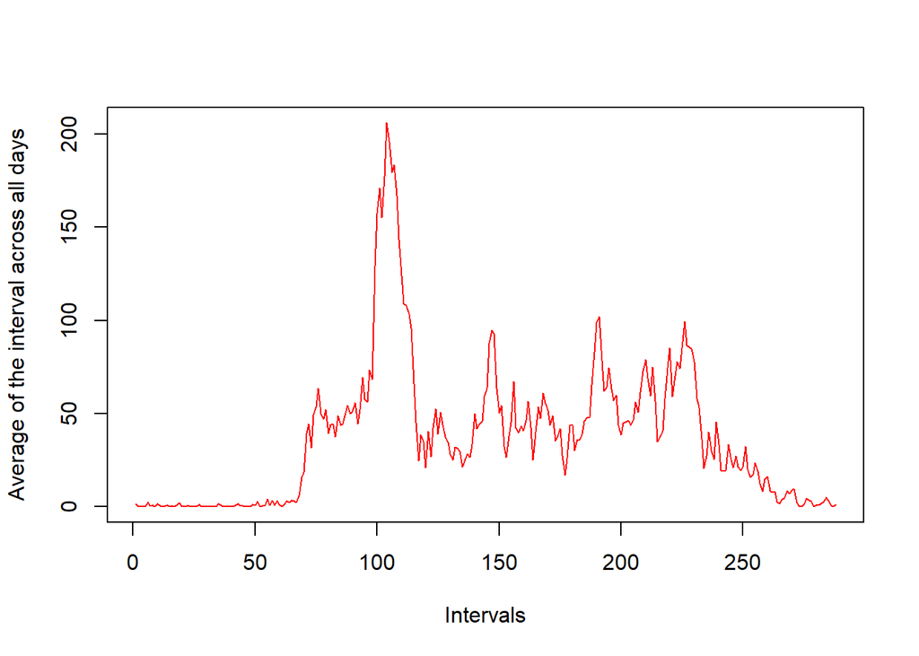

```r
average_daily_pattern <- activity %>% group_by(interval) %>% summarise(average=mean(steps,na.rm=TRUE))
plot(x = 1:nrow(average_daily_pattern),y = average_daily_pattern$average,type = "l",
     col = "red",xlab="Intervals",
     ylab = "Average of the interval across all days")
```

2.) Which 5-minute interval, on average across all the days in the dataset, contains the maximum number of steps?

```r
max_number_of_steps_interval <- filter(average_daily_pattern, average==max(average))
max_number_of_steps_interval
```

```
## # A tibble: 1 x 2
##   interval average
##      <int>   <dbl>
## 1      835    206.
```

# Imputing Missing values

1.) Calculate and report the total number of missing values in the dataset (i.e. the total number of rows with NAs)

```r
sum(is.na(activity$steps))
```

```
## [1] 2304
```

2.) Devise a strategy for filling in all of the missing values in the dataset. The strategy does not need to be sophisticated. For example, you could use the mean/median for that day, or the mean for that 5-minute interval, etc.

The strategy that I did is to fill in the datapoint with missing values with the mean of the steps taken across all dates

3.) Create a new dataset that is equal to the original dataset but with the missing data filled in

```r
impute_mean <- activity
with_na <- is.na(impute_mean$steps)
impute_mean$steps[with_na] <- mean(impute_mean$steps, na.rm = TRUE)
```

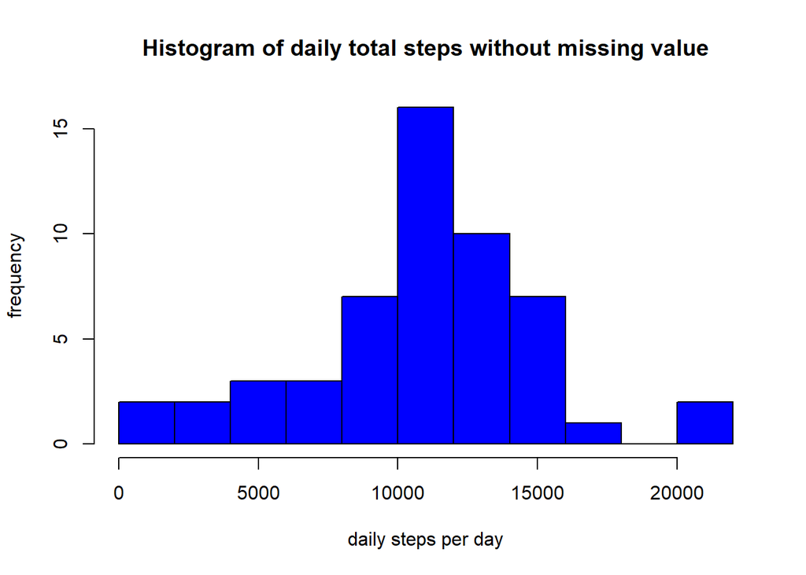

```r
without_na <- activity[with_na == FALSE,]

steps_daily <- tapply(without_na$steps, without_na$date, sum, na.rm=TRUE, simplify=T)

hist(x=steps_daily,
     col="blue",
     xlab="daily steps per day",
     breaks = 15,
     ylab="frequency",
     main="Histogram of daily total steps without missing value")
```

```r
mean(steps_daily)
```

```
## [1] 10766.19
```

```r
median(steps_daily)
```

```
## [1] 10765
```

# Are there differences in activity patterns between weekdays and weekends?

1.) Create a new factor variable in the dataset with two levels - “weekday” and “weekend” indicating whether a given date is a weekday or weekend day.

```r
activity_new <- mutate(without_na, day = ifelse(weekdays(without_na$date) == "Saturday" | weekdays(without_na$date) == "Sunday", "weekend", "weekday"))
activity_new$day<- as.factor(activity_new$day)
head(activity_new)
```

```
##   steps       date interval     day
## 1     0 2012-10-02        0 weekday
## 2     0 2012-10-02        5 weekday
## 3     0 2012-10-02       10 weekday
## 4     0 2012-10-02       15 weekday
## 5     0 2012-10-02       20 weekday
## 6     0 2012-10-02       25 weekday
```

```r
str(activity_new)
```

```
## 'data.frame':    15264 obs. of  4 variables:
##  $ steps   : int  0 0 0 0 0 0 0 0 0 0 ...
##  $ date    : Date, format: "2012-10-02" "2012-10-02" ...
##  $ interval: int  0 5 10 15 20 25 30 35 40 45 ...
##  $ day     : Factor w/ 2 levels "weekday","weekend": 1 1 1 1 1 1 1 1 1 1 ...
```

2.) Make a panel plot containing a time series plot (i.e.type = “l”) of the 5-minute interval (x-axis) and the average number of steps taken, averaged across all weekday days or weekend days (y-axis). See the README file in the GitHub repository to see an example of what this plot should look like using simulated data.

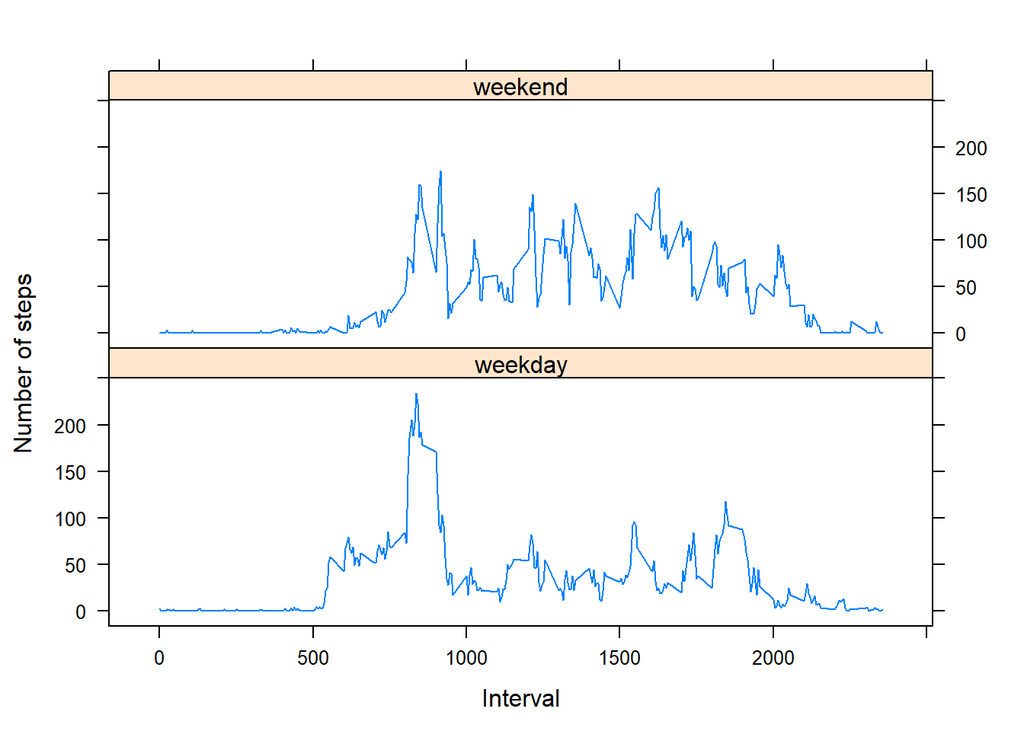

```r
without_na_new <- aggregate(steps ~ day+interval, data=activity_new, FUN=mean)
xyplot(steps ~ interval | factor(day),
       layout = c(1, 2),
       xlab="Interval",
       ylab="Number of steps",
       type="l",
       lty=1,
       data=without_na_new)
```